# Is PCA Your Best Friend?

Matt Curcio

2022-04-13

## Why?

It reveals the (*spooky*) hidden structure in your dataset.

1. Identify important and/or similar features,
2. Reduce the dimensionality of the data,
3. Decrease redundancy in the data,
4. Filter out of the noise from the data,
5. Compress the data,
6. Prepare the data for further analysis using other techniques.

Use Kaggle Data:

https://www.kaggle.com/datasets/jillanisofttech/diabetes-disease-updated-dataset

- This dataset is originally from the National Institute of Diabetes and Digestive and Kidney Diseases.
- The objective is to predict based on diagnostic measurements whether a patient has gestational diabetes.

### Load diabetes dataset

```r
library(readr)
diabetes <- read_csv("diabetes.csv",
                     col_types = cols(Outcome = col_factor(levels = c("0","1"))))

#View(diabetes)
#str(diabetes)
```

### Six number summary of `diabetes.csv`

```r
summary(diabetes)
```

```
##   Pregnancies        Glucose      BloodPressure    SkinThickness
##  Min.   : 0.000   Min.   :  0.0   Min.   :  0.00   Min.   : 0.00
##  1st Qu.: 1.000   1st Qu.: 99.0   1st Qu.: 62.00   1st Qu.: 0.00
##  Median : 3.000   Median :117.0   Median : 72.00   Median :23.00
##  Mean   : 3.845   Mean   :120.9   Mean   : 69.11   Mean   :20.54
##  3rd Qu.: 6.000   3rd Qu.:140.2   3rd Qu.: 80.00   3rd Qu.:32.00
##  Max.   :17.000   Max.   :199.0   Max.   :122.00   Max.   :99.00
##     Insulin           BMI        DiabetesPedigreeFunction      Age
##  Min.   :  0.0   Min.   : 0.00   Min.   :0.0780           Min.   :21.00
##  1st Qu.:  0.0   1st Qu.:27.30   1st Qu.:0.2437           1st Qu.:24.00
##  Median : 30.5   Median :32.00   Median :0.3725           Median :29.00
##  Mean   : 79.8   Mean   :31.99   Mean   :0.4719           Mean   :33.24
##  3rd Qu.:127.2   3rd Qu.:36.60   3rd Qu.:0.6262           3rd Qu.:41.00
##  Max.   :846.0   Max.   :67.10   Max.   :2.4200           Max.   :81.00
##  Outcome
##  0:500
##  1:268
##
##
##
##
```

### Partition Data

- Divide dataset into training dataset and test datasets.

```r
set.seed(2022)

#remove rows with NA value in any column
diabetes <- na.omit(diabetes)

ind <- sample(2, nrow(diabetes), replace = TRUE, prob = c(0.8, 0.2))

training <- diabetes[ind==1,]
testing  <- diabetes[ind==2,]
```

### Correlation Matrix

- Check the correlation between independent variables.
- Remove the factor variable from the dataset for correlation data analysis.

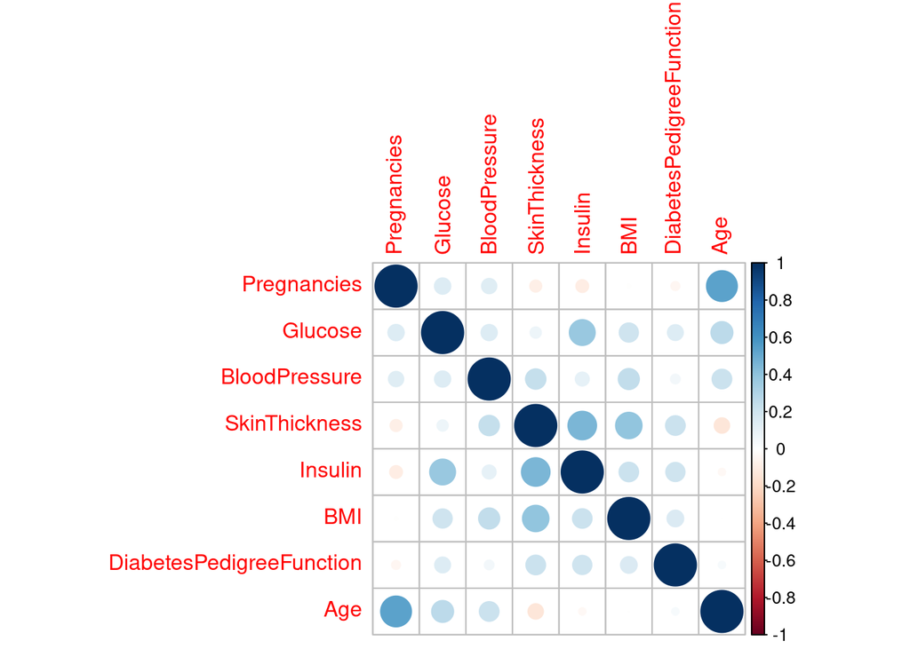

```r
library(corrplot)

diabetes_no_outcome <- subset(training, select = -9)

# computing correlation matrix
cor_data = cor(diabetes_no_outcome)

corrplot(cor_data)
```

#### See: [Correlation Plots](https://r-charts.com/correlation/corplot/)

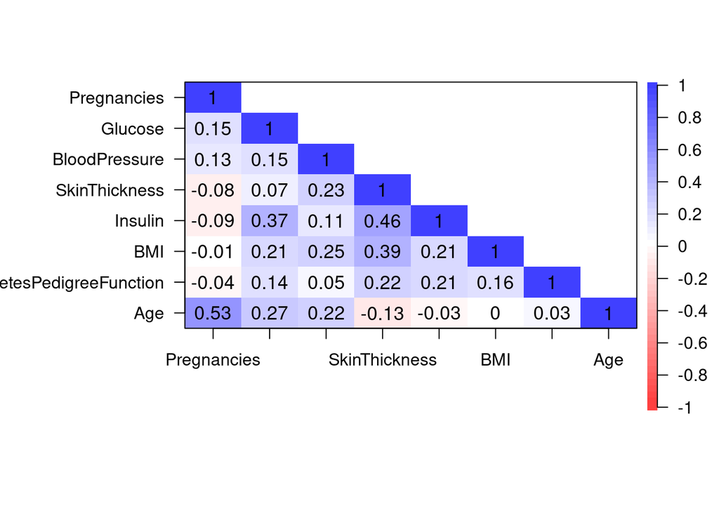

```r
library(psych)

corPlot(cor_data, cex = 1.1, upper = FALSE)
```

## Principal Component Analysis

- Principal Component Analysis is based on only independent variables.
- We’ll use: `prcomp`, [rdocumentation.org](https://www.rdocumentation.org/packages/stats/versions/3.6.2/topics/prcomp)

| Scaling Method | Form |
| --- | --- |
| Center | $f(x) = x_i - mean(x)$ |
| Normalization | $\large f(x) = \frac{x_i - mean(x)}{std~ dev(x)}$ |

```r
pc <- prcomp(training[,-9], center = TRUE, scale. = TRUE)

attributes(pc)
```

```
## $names
## [1] "sdev"     "rotation" "center"   "scale"    "x"
##
## $class
## [1] "prcomp"
```

#### Print the results stored in variable `pc`, **BUT SO, WHAT?**

```r
print(pc)
```

```
## Standard deviations (1, .., p=8):
## [1] 1.4616410 1.3177296 1.0112706 0.9329814 0.8482954 0.8414637 0.6567209
## [8] 0.6124730
##
## Rotation (n x k) = (8 x 8):
##                                 PC1         PC2         PC3          PC4
## Pregnancies              0.05755012  0.60828252 -0.06254653  0.101439873
## Glucose                  0.38103064  0.24553850  0.47926281 -0.369839187
## BloodPressure            0.32987306  0.20003909 -0.58078018 -0.001799202
## SkinThickness            0.47225372 -0.27112108 -0.23610492  0.027528613
## Insulin                  0.47626984 -0.16682937  0.35258537 -0.317290256
## BMI                      0.43447986 -0.08440622 -0.35459018  0.009260946
## DiabetesPedigreeFunction 0.29921720 -0.09292514  0.34719229  0.860951511
## Age                      0.12052880  0.64233124  0.05244815  0.100853800
##                                  PC5         PC6         PC7         PC8
## Pregnancies               0.44415910  0.26711861  0.53396312 -0.24234681
## Glucose                  -0.43307371  0.01630579  0.32444195  0.36738447
## BloodPressure            -0.26142274 -0.63812652  0.14679710 -0.12947037
## SkinThickness             0.52444907  0.04552210  0.04143035  0.60673789
## Insulin                   0.34662683 -0.20050463 -0.20384810 -0.56430411
## BMI                      -0.35915978  0.68355517 -0.14836536 -0.24500446
## DiabetesPedigreeFunction -0.13243781 -0.10629152  0.08600773 -0.06179806
## Age                       0.07138284 -0.01887801 -0.71790758  0.19778248
```

## Bi-Plot

- A *better* method for viewing principal component analysis !?!

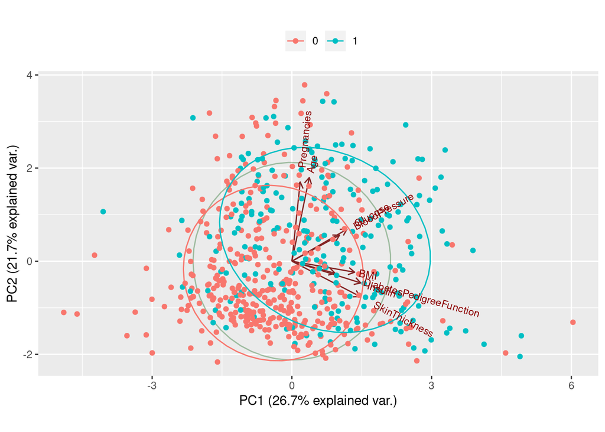

```r
#library(devtools)
#install_github("vqv/ggbiplot")
library(ggbiplot)

g <- ggbiplot(pc,
              obs.scale = 1,
              var.scale = 1,
              groups = training$Outcome,
              ellipse = TRUE,
              circle = TRUE,
              ellipse.prob = 0.68)

g <- g + scale_color_discrete(name = '')
g <- g + theme(legend.direction = 'horizontal',
               legend.position = 'top')
print(g)
```

## Conclusions:

#### The Good, The Bad & The Ugly

The Good  
1. PCA preserves the global structure among the data points,  
2. It is efficiently applied to large data sets,  
3. PCA may provide information on important features found in your data.

The Bad  
1. PCA can easily suffer from scale complications,  
2. PCA is susceptible to outliers,  
- For example: If the sample size is small this can influence scaling and relative point placement,

The Ugly  
1. Intuitive understanding can be tricky.